# Biodistribution

Zach McKay

2022-09-22

# Import and view data

We can see that the data structure has caused the column names to not be imported correctly, and that the observation point is not recorded for each observation but rather at the top of each set of observations.

```
## -------------------------------------------------------- Delimiter: "," chr
## (18): May '22, ...2, ...3, ...4, ...5, ...6, ...7, ...8, ...9, ...10, ..... dbl
## (1): ...19
```

```
## # A tibble: 6 x 19
##   `May '22` ...2  ...3   ...4    ...5  ...6  ...7  ...8  ...9  ...10 ...11 ...12
##   <chr>     <chr> <chr>  <chr>   <chr> <chr> <chr> <chr> <chr> <chr> <chr> <chr>
## 1 Mouse no. Ltr   Intrvl Ser pfu Spln~ Spln~ Ipsi~ Ipsi~ Cont~ Cont~ Kidn~ Kidn~
## 2 539       A     24hpi  0       90    2037  170   2941~ 120   33333 180   19
## 3 542       B     24hpi  0       100   333   190   1403~ 160   25000 170   59
## 4 548       C     24hpi  0       110   240   230   2391~ 260   51282 180   130
## 5 546       D     24hpi  0       130   256   180   1388~ 160   25000 200   500
## 6 552       E     24hpi  0       60    333   180   1111~ 150   2222  180   0
## # ... with 7 more variables: ...13 <chr>, ...14 <chr>, ...15 <chr>,
## #   ...16 <chr>, ...17 <chr>, ...18 <chr>, ...19 <dbl>
## # i Use `colnames()` to see all variable names
```

## Separate data sets into separate objects and clean up data

We will clean up the data by first splitting the data into three separate sets so that each observation point can be cleaned up for later recombination.

```
## # A tibble: 6 x 19
##   `May '22` ...2  ...3   ...4    ...5  ...6  ...7  ...8  ...9  ...10 ...11 ...12
##   <chr>     <chr> <chr>  <chr>   <chr> <chr> <chr> <chr> <chr> <chr> <chr> <chr>
## 1 Mouse no. Ltr   Intrvl Ser pfu Spln~ Spln~ Ipsi~ Ipsi~ Cont~ Cont~ Kidn~ Kidn~
## 2 539       A     24hpi  0       90    2037  170   2941~ 120   33333 180   19
## 3 542       B     24hpi  0       100   333   190   1403~ 160   25000 170   59
## 4 548       C     24hpi  0       110   240   230   2391~ 260   51282 180   130
## 5 546       D     24hpi  0       130   256   180   1388~ 160   25000 200   500
## 6 552       E     24hpi  0       60    333   180   1111~ 150   2222  180   0
## # ... with 7 more variables: ...13 <chr>, ...14 <chr>, ...15 <chr>,
## #   ...16 <chr>, ...17 <chr>, ...18 <chr>, ...19 <dbl>
## # i Use `colnames()` to see all variable names
```

```
## # A tibble: 6 x 19
##   `May '22` ...2  ...3   ...4    ...5  ...6  ...7  ...8  ...9  ...10 ...11 ...12
##   <chr>     <chr> <chr>  <chr>   <chr> <chr> <chr> <chr> <chr> <chr> <chr> <chr>
## 1 July '22  <NA>  <NA>   <NA>    <NA>  <NA>  <NA>  <NA>  <NA>  <NA>  <NA>  <NA>
## 2 Mouse no. Ltr   Intrvl Spln (~ plaq~ Spln~ Ipsi~ plaq~ Ipsi~ Cont~ plaq~ Cont~
## 3 1827      A     24     100     0     0     135   9x10~ 2250~ 180   4x10~ 74074
## 4 1828      B     24     110     200   6060  130   5x10~ 1950~ 150   3x10~ 66667
## 5 1830      C     24     100     40    1333  175   6x10~ 1142~ 160   6x10~ 1250~
## 6 1833      D     24     80      ND    ND    180   6x10~ 1111~ 160   7x10~ 1458~
## # ... with 7 more variables: ...13 <chr>, ...14 <chr>, ...15 <chr>,
## #   ...16 <chr>, ...17 <chr>, ...18 <chr>, ...19 <dbl>
## # i Use `colnames()` to see all variable names
```

```
## # A tibble: 6 x 19
##   `May '22`    ...2  ...3  ...4  ...5  ...6  ...7  ...8  ...9  ...10 ...11 ...12
##   <chr>        <chr> <chr> <chr> <chr> <chr> <chr> <chr> <chr> <chr> <chr> <chr>
## 1 August '22 ~ <NA>  <NA>  <NA>  <NA>  <NA>  <NA>  <NA>  <NA>  <NA>  <NA>  <NA>
## 2 Mouse no.    Ltr   Intr~ Ipsi~ plaq~ Ipsi~ Cont~ plaq~ Cont~ CLN ~ plaq~ CLN ~
## 3 Ntg          A     120   160   9x10~ 1873  150   4x10~ 889   15    <NA>  0
## 4 Ntg          B     120   180   8x10~ 1481  200   5x10~ 833   15    <NA>  0
## 5 Ntg          C     120   150   4x10~ 889   160   2x10~ 4162  15    <NA>  2200
## 6 Ntg          D     120   140   2.5x~ 595   160   3x10~ 6244  20    <NA>  0
## # ... with 7 more variables: ...13 <chr>, ...14 <chr>, ...15 <chr>,
## #   ...16 <chr>, ...17 <chr>, ...18 <chr>, ...19 <dbl>
## # i Use `colnames()` to see all variable names
```

# Clean up data

We need to rename the columns to useful descriptors for each observation. We will use the mouse, ltr (for letter), and total pfu, weight, and calculate pfu/g based on what is available for each tissue type. We will then delete blank or unnecessary rows (rows that currently contain data type), and an additional column for the observaiton point for later recombinaiton.

```
## # A tibble: 6 x 15
##   mouse ltr   intrvl ser_pfu spleen_mg spleen_~1 ipsi_mg ipsi_~2 contr~3 contr~4
##   <chr> <chr> <chr>  <chr>   <chr>     <chr>     <chr>   <chr>   <chr>   <chr>
## 1 539   A     24hpi  0       90        2037      170     2941176 120     33333
## 2 542   B     24hpi  0       100       333       190     1403508 160     25000
## 3 548   C     24hpi  0       110       240       230     2391304 260     51282
## 4 546   D     24hpi  0       130       256       180     1388888 160     25000
## 5 552   E     24hpi  0       60        333       180     1111111 150     2222
## 6 545   F     48hpi  0       120       0         180     222222  170     3137
## # ... with 5 more variables: kidney_mg <chr>, kidney_pfu_g <chr>, cln_mg <chr>,
## #   cln_pfu_g <chr>, obs_pt <chr>, and abbreviated variable names
## #   1: spleen_pfu_g, 2: ipsi_pfu_g, 3: contra_mg, 4: contra_pfu_g
## # i Use `colnames()` to see all variable names
```

We will perform similar data cleanup for the July data set.

```
## # A tibble: 6 x 20
##   mouse ltr   intrvl spleen_mg spleen_~1 splee~2 ipsi_mg ipsi_~3 ipsi_~4 contr~5
##   <chr> <chr> <chr>  <chr>     <chr>     <chr>   <chr>   <chr>   <chr>   <chr>
## 1 1827  A     24     100       0         0       135     9x10e4~ 2250000 180
## 2 1828  B     24     110       200       6060    130     5x10e4~ 1950195 150
## 3 1830  C     24     100       40        1333    175     6x10e5~ 114285~ 160
## 4 1833  D     24     80        ND        ND      180     6x10e5~ 111111~ 160
## 5 1835  E     24     90        ND        ND      170     5x10e5~ 9803922 150
## 6 1838  F     48     120       ND        ND      150     3x10e4~ 666667  170
## # ... with 10 more variables: contra_plaques <chr>, contra_pfu_g <chr>,
## #   kidney_mg <chr>, kidney_plaques <chr>, kidney_pfu_g <chr>, cln_mg <chr>,
## #   cln_plaques <chr>, cln_pfu_g <chr>, ...19 <dbl>, obs_pt <chr>, and
## #   abbreviated variable names 1: spleen_plaques, 2: spleen_pfu_g,
## #   3: ipsi_plaques, 4: ipsi_pfu_g, 5: contra_mg
## # i Use `colnames()` to see all variable names
```

And the same process for the August data set.

```
## # A tibble: 6 x 13
##   mouse ltr   intrvl ipsi_mg ipsi_plaques ipsi_~1 contr~2 contr~3 contr~4 cln_mg
##   <chr> <chr> <chr>  <chr>   <chr>        <chr>   <chr>   <chr>   <chr>   <chr>
## 1 Ntg   A     120    160     9x10e1       1873    150     4x10e1~ 889     15
## 2 Ntg   B     120    180     8x10e1       1481    200     5x10e1~ 833     15
## 3 Ntg   C     120    150     4x10e1/300uL 889     160     2x10e2~ 4162    15
## 4 Ntg   D     120    140     2.5x10e1/30~ 595     160     3x10e2~ 6244    20
## 5 Ntg   E     120    150     4x10e2/300uL 8888    180     2.5x10~ 463     15
## 6 Tg    A     120    160     6x10e2/300uL 12499   170     1x10e1~ 195     20
## # ... with 3 more variables: cln_plaques <chr>, cln_pfu_g <chr>, obs_pt <chr>,
## #   and abbreviated variable names 1: ipsi_pfu_g, 2: contra_mg,
## #   3: contra_plaques, 4: contra_pfu_g
## # i Use `colnames()` to see all variable names
```

# Combine data into new set

Now we can recombine the cleaned up data sets into a single data set. We also want to convert each data type to numeric where possible and convert some observations to n/a. Also, we will perform our analyses using logarithmic scales, so to correct for 0 values, we will perform our analyses by using x+1, so each numeric value will have 1 added to it.

[output not shown]

# Create and save plots by tissue type

We look at the data pooled across observation points for each graph by tissue type and separate the data by time point. Since the August data set also includes the non-transgenic mice, we will filter those mice out for the final analysis. Each graph will be saved for later use

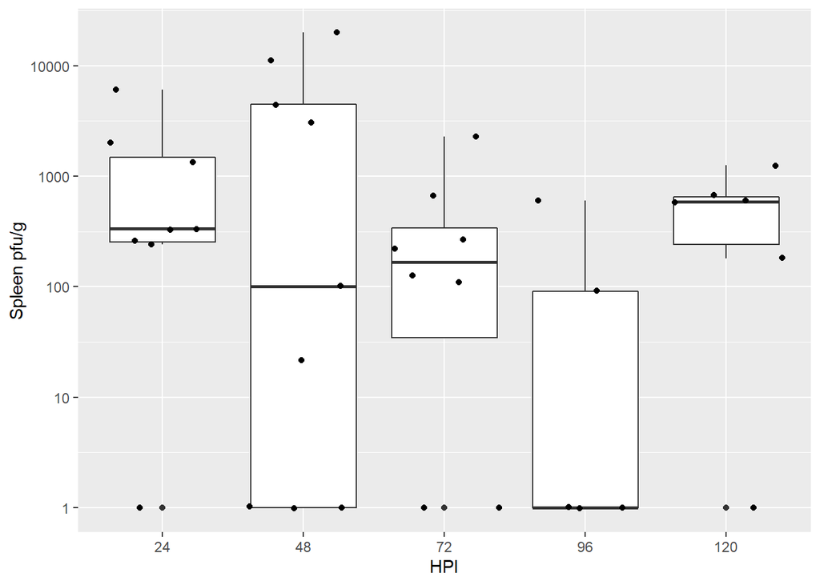

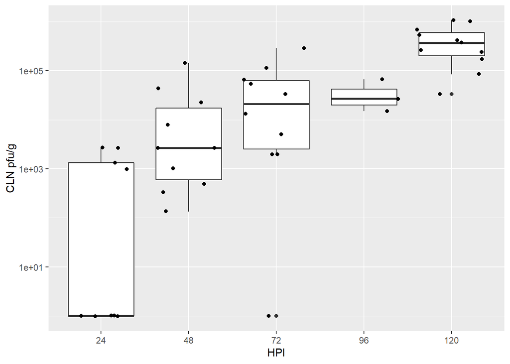

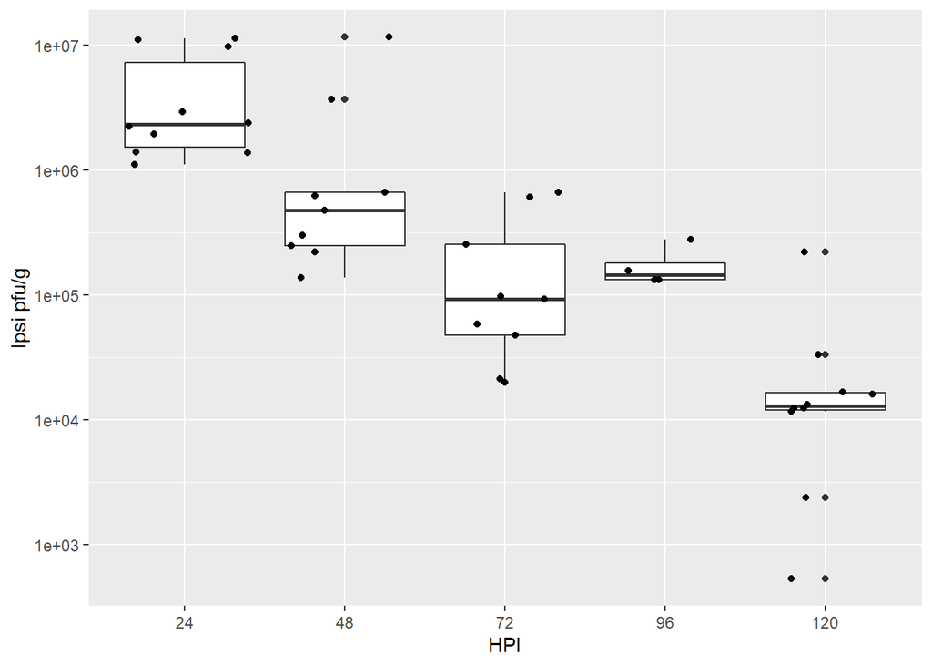

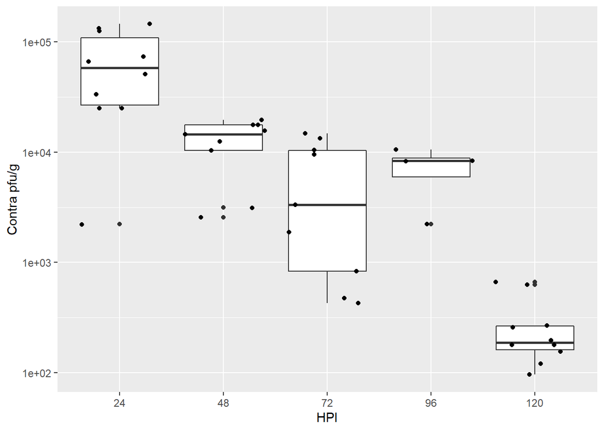

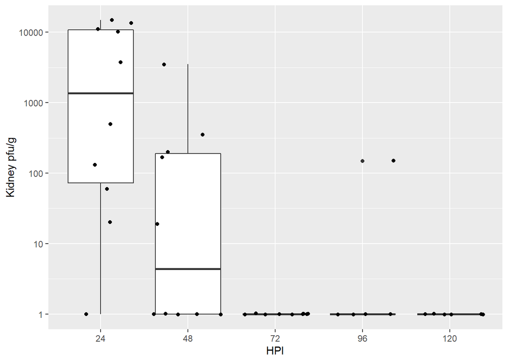